# cleaningdatapt1

### 9 ROWS

### 2 ROWS that is missing multiple variables

## TYPE:

### Numeric

### Categorical

## replace w constant, 0 = no bueno

## find mean

## find median

### When we impute we have several options (let’s assume that we are talking about numeric variables for now):

- Replace the missing values with a constant (often zero)
- Replace the missing values with the mean of the non-missing values
- Replace the missing values with the median of the non-missing values

We’ll use a package called “**mice**” to help us with the imputation. This package uses patterns in the data to estimate what the missing values “**should**” be.

Let’s demonstrate this by imputing one of the numeric variables with missing values. I’ll pick “bill_length_mm”. We’ll try a few different imputation methods using mice.

##### *predictive mean matching = PMM*

```r
#OLD VERSION

#mice_imputed = data.frame(  #creates a data frame with the original and imputed values
  #original = penguins$bill_length_mm,
  #imputed_pmm = complete(mice(penguins, method = "pmm"))$bill_length_mm,
  #imputed_cart = complete(mice(penguins, method = "cart"))$bill_length_mm
#)
#mice_imputed
```

```r
set.seed(628)
mice_imputed = data.frame(  #creates a data frame with the original and imputed values
  original = penguins$bill_length_mm,
  imputed_pmm = complete(mice(penguins, method = "pmm"))$bill_length_mm,
  imputed_cart = complete(mice(penguins, method = "cart"))$bill_length_mm
)
mice_imputed
```

```
    original imputed_pmm imputed_cart
1       39.1        39.1         39.1
2       39.5        39.5         39.5
3       40.3        40.3         40.3
4         NA        45.8         39.1
5       36.7        36.7         36.7
6       39.3        39.3         39.3
7       38.9        38.9         38.9
8       39.2        39.2         39.2
9       34.1        34.1         34.1
10      42.0        42.0         42.0
11      37.8        37.8         37.8
12      37.8        37.8         37.8
13      41.1        41.1         41.1
14      38.6        38.6         38.6
```

[output cut: 330 more lines]

We then choose the imputation that gives us the most reasonable distribution.

NOTE: In this case we are only imputing TWO values so it will be very difficult to tell anything!

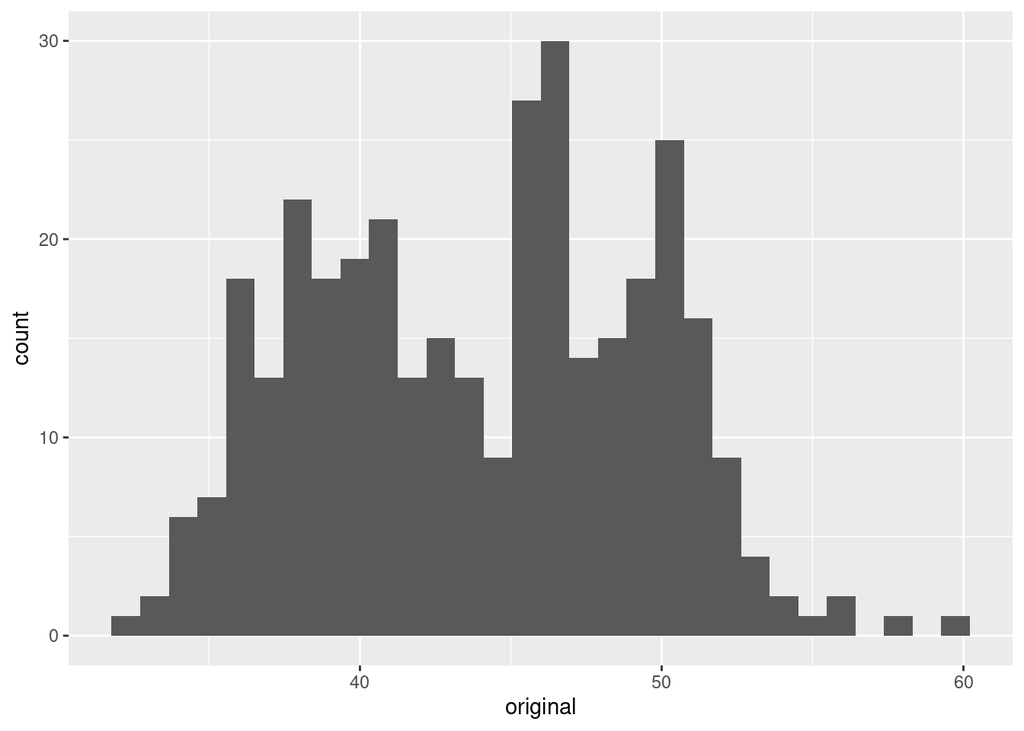

```r
ggplot(mice_imputed,aes(x=original)) + geom_histogram()
```

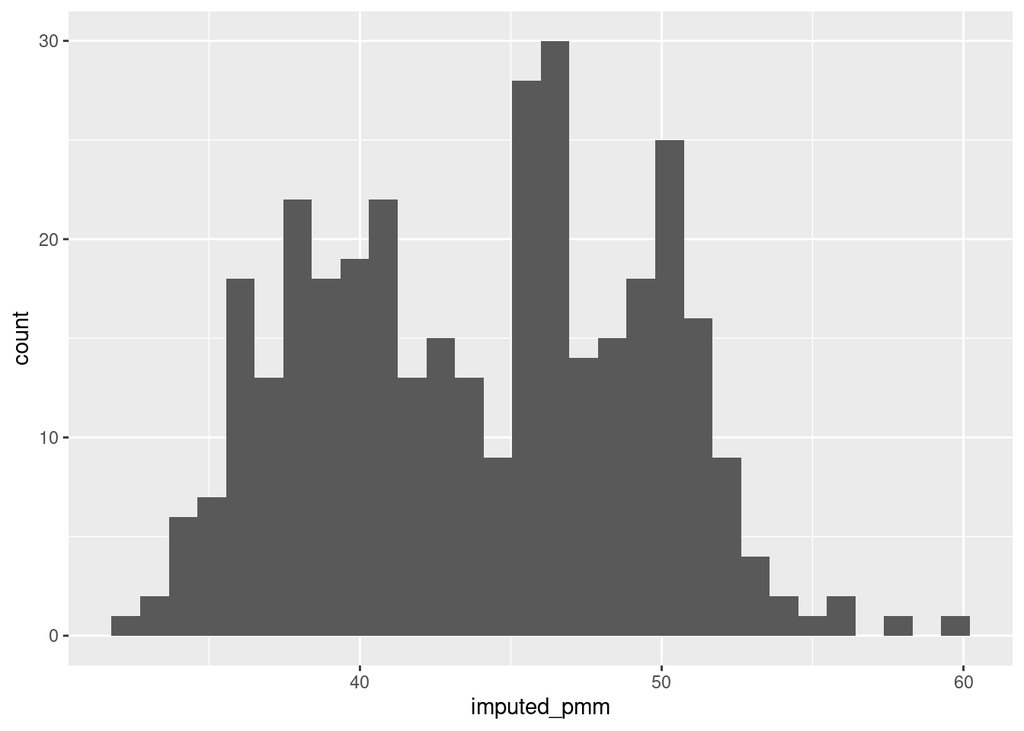

```r
ggplot(mice_imputed,aes(x=imputed_pmm)) + geom_histogram()
```

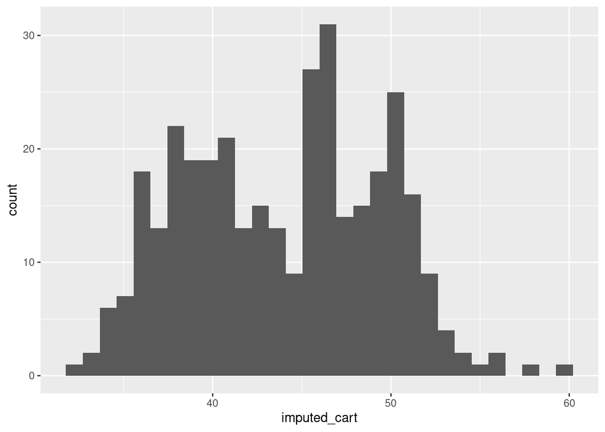

```r
ggplot(mice_imputed,aes(x=imputed_cart)) + geom_histogram()
```

We’re done with this lecture. Let’s render our work. Before we do this we need to check:

- There are no errors in the code. When we render all of the code is run. If there are any errors, the render will fail.
- We have commented out any install.packages commands. This command cannot be executed during a render.

If we are happy that those things are good, then we can render this lecture to an HTML file.

Start by making sure any changes are saved. Then click “Render” (top of this window with a blue arrow).